# Semantic Segmentation on EO Imagery

### FCN-ResNet50 vs DeepLabV3 vs U-Net vs SegFormer (LandCoverAI Dataset)

## Objective

This notebook presents a structured comparison of multiple semantic segmentation architectures on Earth Observation (EO) imagery.

We evaluate:

- FCN-ResNet50 (baseline)
- DeepLabV3-ResNet50
- U-Net (TorchGeo)
- U-Net-ResNet50
- SegFormer-B0 (transformer-based)

Goal: understand the trade-offs between classical CNN-based segmentation, encoder–decoder architectures, and transformer-based models under a controlled setup.

## Workflow

1. Data loading and inspection
2. Image Preprocessing
3. Model training (5 architectures)
4. Evaluation and comparison (OA, IoU, mIoU)
5. Visualization (predictions vs. ground truth masks)

## Dataset

We use a **100-sample subset of the LandCoverAI dataset**:

- RGB aerial imagery
- Pixel-level annotations (building, woodland, water, road)
- Image–mask pairs
- Resized to a consistent input size

The dataset is split into training, validation, and test sets.

## Data Inspection

Sample image–mask pairs are inspected to verify annotation quality and reveal class imbalance, thin structures, and boundary ambiguity.

```python
import torch, torchvision, torchgeo
print("PyTorch:", torch.__version__)
print("TorchVision:", torchvision.__version__)
print("TorchGeo:", torchgeo.__version__)
```

```
PyTorch: 2.10.0+cu126
TorchVision: 0.25.0+cu126
TorchGeo: 0.9.0
```

```python
import os, random
import torch
import torch.nn as nn
import torch.nn.functional as F
import torch.optim as optim
from torch.utils.data import DataLoader, Subset
import torchvision.transforms as T
import torchvision.models.segmentation as models

import matplotlib.pyplot as plt
import numpy as np

from torchgeo.datasets import LandCoverAI
from sklearn.metrics import confusion_matrix

from torchgeo.models import unet
import segmentation_models_pytorch as smp
from transformers import SegformerForSemanticSegmentation

from pathlib import Path

device = torch.device("cuda" if torch.cuda.is_available() else "cpu")
print("Using device:", device)
```

```
Using device: cuda
```

```python
DATA_ROOT = Path("./data/landcoverai")
DATA_ROOT.mkdir(parents=True, exist_ok=True)

train_ds_full = LandCoverAI(root=DATA_ROOT, split="train", download=True)
val_ds_full   = LandCoverAI(root=DATA_ROOT, split="val", download=True)
test_ds_full  = LandCoverAI(root=DATA_ROOT, split="test", download=True)

# Controlled subset (100 samples: 60 train / 20 val / 20 test)
rng = np.random.default_rng(42)
train_idx = rng.choice(len(train_ds_full), size=min(60, len(train_ds_full)), replace=False)
val_idx   = rng.choice(len(val_ds_full), size=min(20, len(val_ds_full)), replace=False)
test_idx  = rng.choice(len(test_ds_full), size=min(20, len(test_ds_full)), replace=False)

train_ds = Subset(train_ds_full, train_idx)
val_ds   = Subset(val_ds_full, val_idx)
test_ds  = Subset(test_ds_full, test_idx)

print("Subset sizes:", len(train_ds), len(val_ds), len(test_ds))
print("Classes:", train_ds_full.classes)
```

```
Subset sizes: 60 20 20
Classes: ('Background', 'Building', 'Woodland', 'Water', 'Road')
```

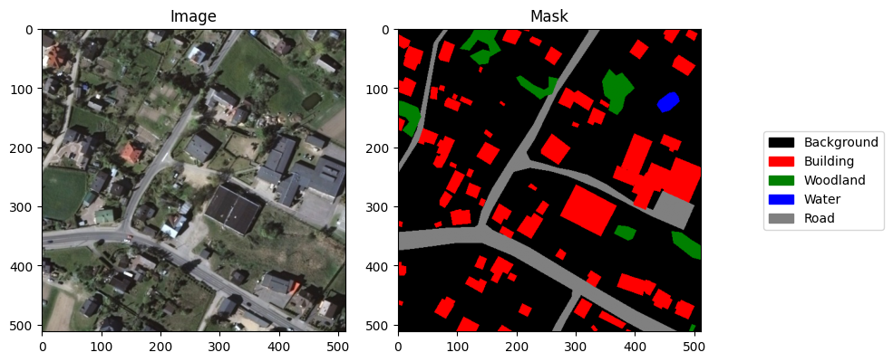

```python
import matplotlib.colors as mcolors
import matplotlib.patches as mpatches

# random inspection option
# sample = random.choice(train_ds)

# fixed samples for reproducibility, representative and edge cases
sample = train_ds[55]

image, mask = sample["image"], sample["mask"]

# normalize for visualization
img_disp = image.permute(1,2,0).numpy()
img_disp = (img_disp - img_disp.min()) / (img_disp.max() - img_disp.min() + 1e-6)

class_names = ["Background", "Building", "Woodland", "Water", "Road"]
colors = ["black", "red", "green", "blue", "gray"]

cmap = mcolors.ListedColormap(colors)
num_classes = len(class_names)

fig, axes = plt.subplots(1, 2, figsize=(8, 4))
axes[0].imshow(img_disp)
axes[0].set_title("Image")

axes[1].imshow(mask, cmap=cmap, vmin=0, vmax=num_classes-1)
axes[1].set_title("Mask")

patches = [mpatches.Patch(color=colors[i], label=class_names[i]) for i in range(num_classes)]
fig.legend(handles=patches, bbox_to_anchor=(1.05, 0.5), loc='center left')

plt.tight_layout()
plt.show()
```

## Image Preprocessing

```python
# resize + normalize images; masks use nearest interpolation to preserve labels
IMG_SIZE = 512

image_tf = T.Compose([
    T.Resize((IMG_SIZE, IMG_SIZE)),
    T.Normalize(mean=[0.485, 0.456, 0.406],
                         std=[0.229, 0.224, 0.225]),
])

mask_tf = T.Compose([
    T.Resize((IMG_SIZE, IMG_SIZE), interpolation=T.InterpolationMode.NEAREST),
])

class WrappedDataset(torch.utils.data.Dataset):
    def __init__(self, base, image_tf=None, mask_tf=None):
        self.base = base
        self.image_tf = image_tf
        self.mask_tf = mask_tf

    def __len__(self):
        return len(self.base)

    def __getitem__(self, idx):
        sample = self.base[idx]
        img, mask = sample["image"], sample["mask"]
        if self.image_tf: img = self.image_tf(img)
        if self.mask_tf: mask = self.mask_tf(mask)
        return img, mask.long()

train_ds_w = WrappedDataset(train_ds, image_tf=image_tf, mask_tf=mask_tf)
val_ds_w   = WrappedDataset(val_ds, image_tf=image_tf, mask_tf=mask_tf)
test_ds_w  = WrappedDataset(test_ds, image_tf=image_tf, mask_tf=mask_tf)

BATCH_SIZE = 4
train_loader = DataLoader(train_ds_w, batch_size=BATCH_SIZE, shuffle=True)
val_loader   = DataLoader(val_ds_w, batch_size=BATCH_SIZE)
test_loader  = DataLoader(test_ds_w, batch_size=1)
```

## Model training (5 architectures)

FCN-ResNet50 (baseline), DeepLabV3-ResNet50, U-Net (TorchGeo), U-Net-ResNet50, and SegFormer-B0 (transformer-based) are trained under a unified pipeline.

Although background is present in the ground truth, it is excluded during training and evaluation to avoid dominance in pixel distribution and to ensure that performance reflects the model’s ability to segment meaningful land-cover classes.

```python
num_classes = len(train_ds_full.classes)

# unified training setup across all architectures for fair comparison

model_name = "fcn"   # "fcn" | "deeplabv3" | "unet" | "segformer"

if model_name == "fcn":
    model = models.fcn_resnet50(weights="COCO_WITH_VOC_LABELS_V1")
    model.classifier[4] = nn.Conv2d(512, num_classes, 1)

elif model_name == "deeplabv3":
    model = models.deeplabv3_resnet50(weights="COCO_WITH_VOC_LABELS_V1")
    model.classifier[4] = nn.Conv2d(256, num_classes, 1)

elif model_name == "unet":
    model = unet(in_channels=3, classes=num_classes)

elif model_name == "unet_resnet50":
    model = smp.Unet(
        encoder_name="resnet50",
        encoder_weights="imagenet",
        in_channels=3,
        classes=num_classes
    )

elif model_name == "segformer":
    model = SegformerForSemanticSegmentation.from_pretrained(
        "nvidia/segformer-b0-finetuned-ade-512-512",
        num_labels=num_classes,
        ignore_mismatched_sizes=True
    )

model = model.to(device)

# ignore background class (index 0) to reduce class imbalance bias
criterion = nn.CrossEntropyLoss(ignore_index=0)

optimizer = optim.Adam(model.parameters(), lr=1e-4)
scheduler = optim.lr_scheduler.StepLR(optimizer, step_size=5, gamma=0.5)
```

```python
# handle different output formats across architectures
def forward_pass(model, imgs, masks=None):
    if model_name in ["fcn", "deeplabv3"]:
        return model(imgs)["out"]

    elif model_name in ["unet", "unet_resnet50"]:
        return model(imgs)

    elif model_name == "segformer":
        out = model(pixel_values=imgs).logits
        if masks is not None:
            out = F.interpolate(out, size=masks.shape[-2:], mode="bilinear", align_corners=False)
        return out

def train_one_epoch(model, loader, optimizer):
    model.train()
    total_loss = 0
    for imgs, masks in loader:
        imgs, masks = imgs.to(device), masks.to(device)
        optimizer.zero_grad()
        out = forward_pass(model, imgs, masks)
        loss = criterion(out, masks)
        loss.backward()
        optimizer.step()
        total_loss += loss.item() * imgs.size(0)
    return total_loss / len(loader.dataset)

def evaluate(model, loader, ignore_index=0):
    model.eval()
    preds, targets = [], []
    with torch.no_grad():
        for imgs, masks in loader:
            imgs, masks = imgs.to(device), masks.to(device)
            out = forward_pass(model, imgs, masks)
            pred = out.argmax(1).cpu().numpy()
            masks = masks.cpu().numpy()

            # mask out ignore_index (background)
            for p, m in zip(pred, masks):
                valid = m != ignore_index
                preds.append(p[valid].flatten())
                targets.append(m[valid].flatten())

    preds = np.concatenate(preds)
    targets = np.concatenate(targets)
    return preds, targets

EPOCHS = 15
best_val_loss = float("inf")
for epoch in range(EPOCHS):
    train_loss = train_one_epoch(model, train_loader, optimizer)
    preds, targets = evaluate(model, val_loader)

    val_loss = np.mean((preds != targets).astype(float))
    print(f"Epoch {epoch+1}/{EPOCHS} - Train loss: {train_loss:.4f}, Val loss: {val_loss:.4f}")
    if val_loss < best_val_loss:
        best_val_loss = val_loss
        # Optional: save best model checkpoint
        # Disabled by default to avoid unintended overwrites during repeated experiments
        # torch.save(model.state_dict(), "best_fcn_landcoverai_subset.pth")

    scheduler.step()
```

[output not shown]

## Evaluation

```python
if Path("best_fcn_landcoverai_subset.pth").exists():
    model.load_state_dict(torch.load("best_fcn_landcoverai_subset.pth", map_location=device, weights_only=True))

preds, targets = evaluate(model, test_loader, ignore_index=0)

num_classes = len(train_ds_full.classes)

cm = confusion_matrix(targets.flatten(), preds.flatten(), labels=list(range(num_classes)))

valid_classes = list(range(1, num_classes))

iou_per_class = cm.diagonal()[valid_classes] / (
    cm.sum(1)[valid_classes] + cm.sum(0)[valid_classes] - cm.diagonal()[valid_classes] + 1e-6
)
miou = iou_per_class.mean()
oa = cm.diagonal()[valid_classes].sum() / cm[valid_classes][:, valid_classes].sum()

print("Overall Accuracy (OA):", oa)
print("Mean IoU (mIoU):", miou)
print("Per-class IoU:")
for i, cls in zip(valid_classes, [train_ds_full.classes[j] for j in valid_classes]):
    print(f"{cls}: {iou_per_class[i-1]:.4f}")
```

```
Overall Accuracy (OA): 0.934492476893792
Mean IoU (mIoU): 0.7023599998708214
Per-class IoU:
Building: 0.6187
Woodland: 0.9618
Water: 0.8514
Road: 0.3775
```

## Experimental Notes

Several variations were explored to identify factors that meaningfully impact segmentation performance beyond the baseline.

## Class-wise Performance Analysis

- Per-class IoU shows clear imbalance (e.g., Woodland ≈ 0.96 vs Building ≈ 0.62 vs Road ≈ 0.38), indicating that OA is dominated by easier classes.
- Woodland achieves high accuracy due to distinct spectral characteristics, while water shows occasional confusion due to RGB similarity with vegetation and other surfaces.
- Roads are the most difficult class due to their thin structure, occlusion (e.g., from trees, shadows, canopy, and buildings), and fragmentation, resulting in low IoU and unstable predictions. They are also frequently under-detected, with many road segments present in the ground truth missing in the predictions.
- Buildings show moderate performance, with errors caused by roof appearance variability (e.g., color, material, reflectance) and confusion with surrounding textures.
- The model tends to over-predict road regions, particularly in unlabeled or ambiguous areas like background, suggesting a reliance on local texture cues rather than global spatial structure.
- Overall, minority and structurally complex classes are significantly harder to segment, making mIoU a more reliable metric than OA.

## Visualization

Full predictions are shown alongside the input image for visual interpretation, while foreground-only predictions are paired with ground truth for evaluation consistency.

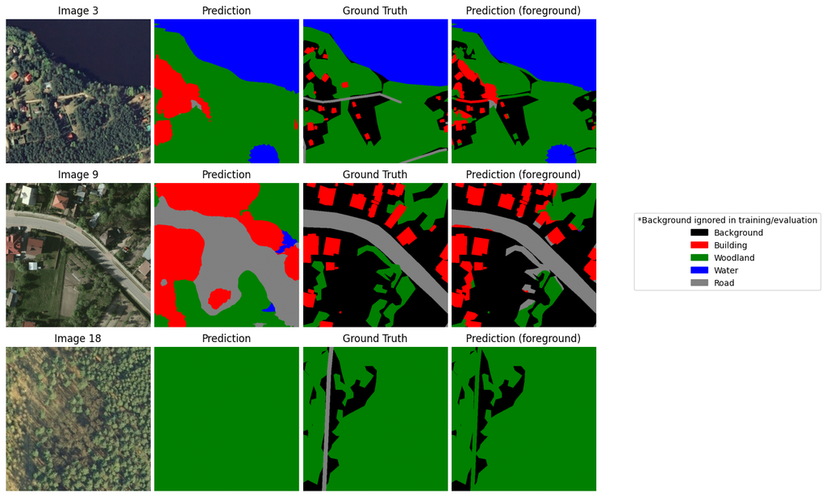

```python
n_samples = 3

# random inspection option
# idxs = random.sample(range(len(test_ds_w)), n_samples)

# fixed samples for reproducibility, representative and edge cases
idxs = [3, 9, 18]

model.eval()
fig, axes = plt.subplots(n_samples, 4, figsize=(10, 2.8 * n_samples))

background_id = 0

with torch.no_grad():
    for row, idx in enumerate(idxs):
        img, gt = test_ds_w[idx]

        # normalize for visualization
        img_disp = img.permute(1, 2, 0).numpy()
        img_disp = (img_disp - img_disp.min()) / (img_disp.max() - img_disp.min() + 1e-6)

        out = forward_pass(model, img.unsqueeze(0).to(device), gt.unsqueeze(0).to(device))
        pred = out.argmax(1).squeeze().cpu().numpy()

        # visualize predictions with background masked (focus on foreground classes)

        fg_mask = (gt != background_id)

        # compare raw prediction vs foreground-only view
        pred_vis = pred.copy()
        pred_vis[~fg_mask] = background_id  # hide background

        pred_rgb = cmap(pred_vis / (num_classes - 1))[:, :, :3]

        # Plot
        axes[row, 0].imshow(img_disp)
        axes[row, 0].set_title(f"Image {idx}")

        axes[row, 1].imshow(pred, cmap=cmap, vmin=0, vmax=num_classes-1)
        axes[row, 1].set_title("Prediction")

        axes[row, 2].imshow(gt, cmap=cmap, vmin=0, vmax=num_classes-1)
        axes[row, 2].set_title("Ground Truth")

        axes[row, 3].imshow(pred_rgb)
        axes[row, 3].set_title("Prediction (foreground)")

        for col in range(4):
            axes[row, col].axis("off")

patches = [mpatches.Patch(color=colors[i], label=class_names[i]) for i in range(num_classes)]
fig.legend(
    handles=patches,
    bbox_to_anchor=(1.05, 0.5),
    loc='center left',
    title="*Background ignored in training/evaluation"
)

plt.tight_layout(pad=0.5)
plt.show()
```

## Model Comparison

| Model | Strength | Limitation | OA | mIoU |
| --- | --- | --- | --- | --- |
| FCN-ResNet50 | Strong baseline, stable | Limited multi-scale context | 0.93 | 0.70 |
| DeepLabV3-ResNet50 | Multi-scale context (ASPP) | Slower, no gain under small data | 0.91 | 0.56 |
| U-Net (TorchGeo) | Efficient encoder–decoder | Weak generalization, struggle with complex feature | 0.84 | 0.43 |
| U-Net-ResNet50 | Improved via pretrained encoder | Still below FCN, sensitive to class imbalance | 0.89 | 0.46 |
| SegFormer-B0 | Global context (transformer) | Data-hungry, underperforms | 0.89 | 0.45 |

Key observations:

- FCN-ResNet50 outperforms all alternatives, confirming that a well-tuned baseline is sufficient.
- Advanced architectures (DeepLabV3, SegFormer) do not improve results, indicating that data is the primary bottleneck rather than model complexity.
- Encoder–decoder (U-Net) underperforms due to limited generalization and training instability.

## Conclusion

- Spatial consistency and label quality are the primary drivers of segmentation performance
- Preserving label fidelity (e.g., correct mask resizing) is critical for stable training and evaluation.
- Under limited data, simpler, well-tuned CNN-based architectures generalize more reliably than transformer-based models.
- Model complexity and augmentation do not compensate for data limitations
- mIoU is a more reliable metric than OA due to class imbalance

This study highlights that preserving spatial structure in data handling and leveraging pretrained representations under careful pipeline design are more impactful than increasing model complexity.